# FA4_EDA

MORILLO, JADE MARCO S.

2025-03-05

##1. Using the Mortality by Latitude data, make a plot of mortality index against mean average temperature. Is it hollow up or hollow down? Try to identify a transformation of one of the variables that will straighten out the relationship, and make a plot of the residuals to check for any remaining patterns.

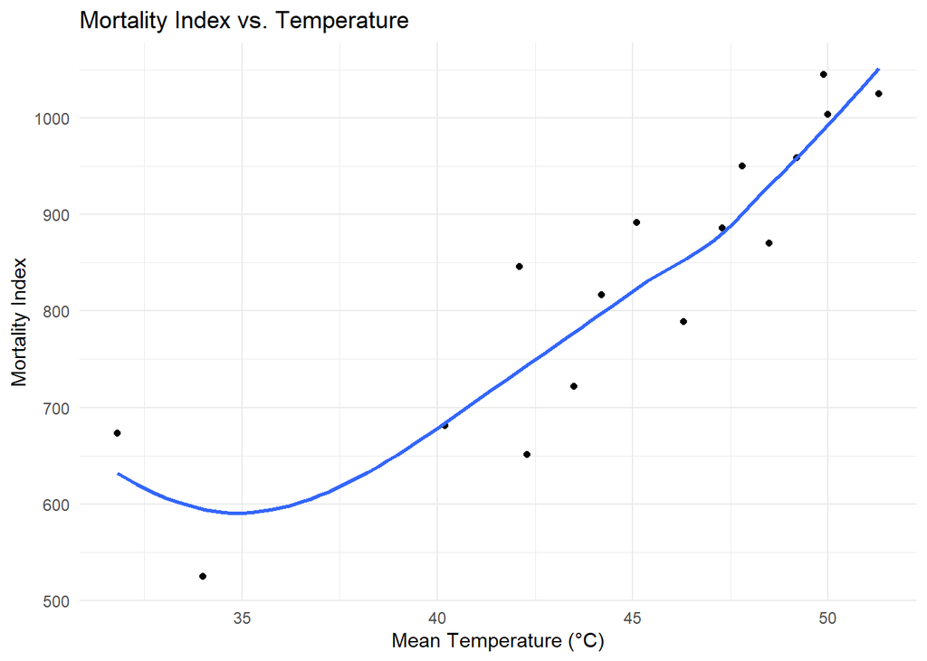

```r
mortality_data <- read.csv("C:/Users/Dindette/Downloads/mortality_by_latitude.csv")

ggplot(mortality_data, aes(x = temperature, y = mortality_index)) +
  geom_point() +
  geom_smooth(method = "loess", se = FALSE) +
  labs(title = "Mortality Index vs. Temperature",
       x = "Mean Temperature (°C)",
       y = "Mortality Index") +
  theme_minimal()
```

It is hollow up thus the mortality goes lower for a while but immediately boosts upward.

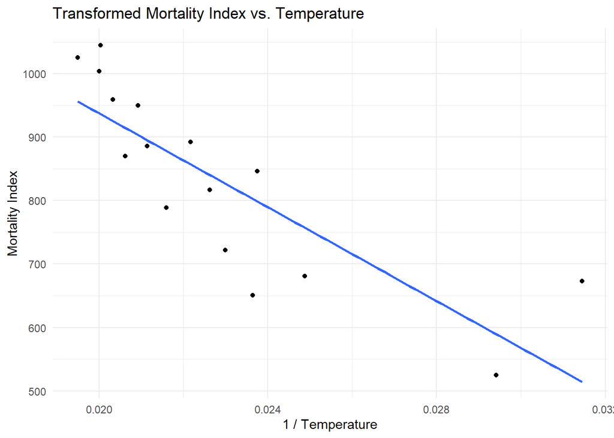

```r
mortality_data <- mortality_data %>%
  mutate(transformed_temp = 1 / temperature)

ggplot(mortality_data, aes(x = transformed_temp, y = mortality_index)) +
  geom_point() +
  geom_smooth(method = "lm", se = FALSE) +
  labs(title = "Transformed Mortality Index vs. Temperature",
       x = "1 / Temperature",
       y = "Mortality Index") +
  theme_minimal()
```

1/Temperature helps make the graph linear.

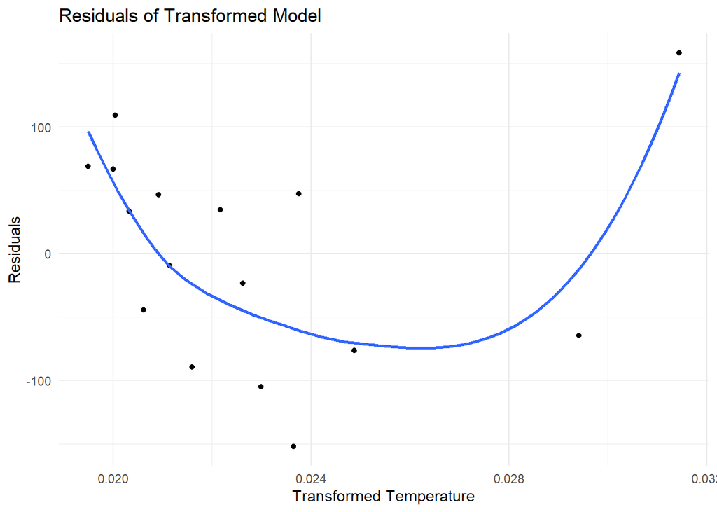

```r
model <- lm(mortality_index ~ transformed_temp, data = mortality_data)
mortality_data$residuals <- residuals(model)

ggplot(mortality_data, aes(x = transformed_temp, y = residuals)) +
  geom_point() +
  geom_smooth(method = "loess", se = FALSE) +
  labs(title = "Residuals of Transformed Model",
       x = "Transformed Temperature",
       y = "Residuals") +
  theme_minimal()
```

The residual curves upward which shows how the transformation does not fully perfect and that there is still some structure in the data.

## 2. Using the same subset of the diamonds dataset, make a plot of log price as a function of carat with a loess smoother. Try several values for the span and degree arguments and comment briefly about your choice.

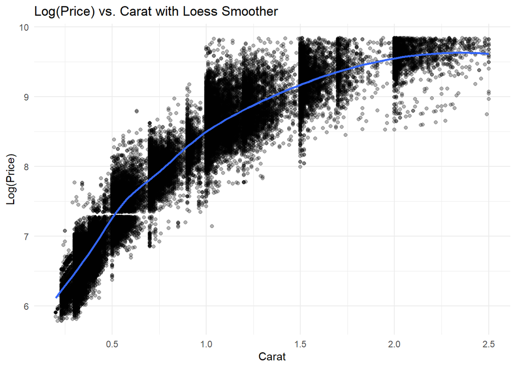

```r
data(diamonds)
diamonds_sub <- diamonds %>% filter(carat <= 2.5)

ggplot(diamonds_sub, aes(x = carat, y = log(price))) +
  geom_point(alpha = 0.3) +
  geom_smooth(method = "loess", span = 0.5, degree = 2, se = FALSE) +
  labs(title = "Log(Price) vs. Carat with Loess Smoother",
       x = "Carat",
       y = "Log(Price)") +
  theme_minimal()
```

This shows how the log(price) of the diamond is directly proportional to the amount of carat however it is not linear as it plateaus as it becomes too high.

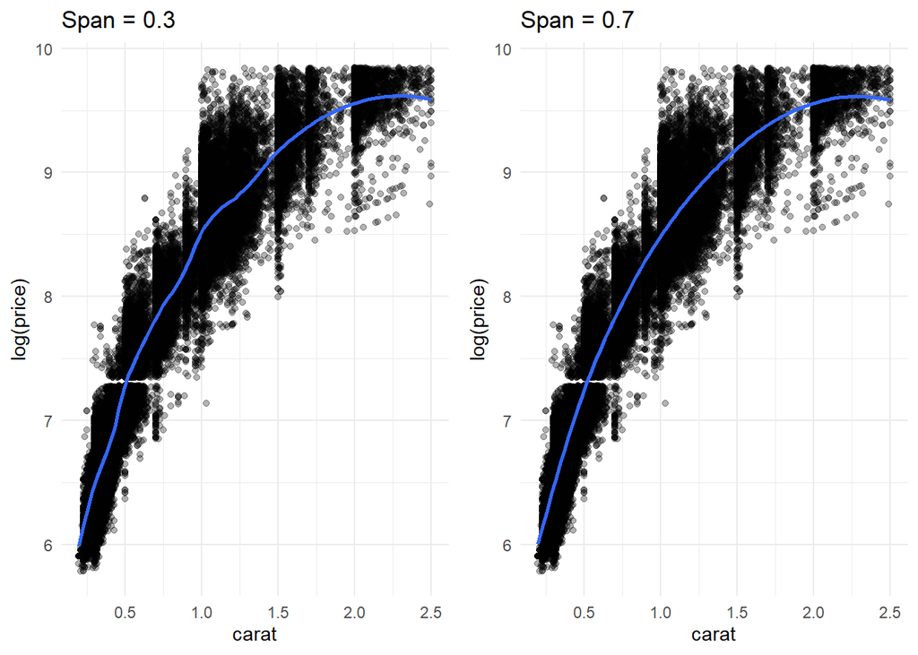

```r
p1 <- ggplot(diamonds_sub, aes(x = carat, y = log(price))) +
  geom_point(alpha = 0.3) +
  geom_smooth(method = "loess", span = 0.3, se = FALSE) +
  labs(title = "Span = 0.3") +
  theme_minimal()

p2 <- ggplot(diamonds_sub, aes(x = carat, y = log(price))) +
  geom_point(alpha = 0.3) +
  geom_smooth(method = "loess", span = 0.7, se = FALSE) +
  labs(title = "Span = 0.7") +
  theme_minimal()

ggarrange(p1, p2, ncol = 2, nrow = 1)
```

0.3 appears wiggly as it follows more closely while 0.7 looks more smooth as it is more lax in following the data.

## 3. Compare the fit of the loess smoother to the fit of the polynomial + step function regression using a plot of the residuals in the two models. Which one is more faithful to the data?

```r
diamonds_sub <- diamonds_sub %>%
  mutate(carat_bins = cut(carat, breaks = c(0, 0.5, 1, 1.5, 2, 2.5), include.lowest = TRUE))

model_poly_step <- lm(log(price) ~ poly(carat, 3) + carat_bins, data = diamonds_sub)

diamonds_sub$resid_poly_step <- residuals(model_poly_step)
```

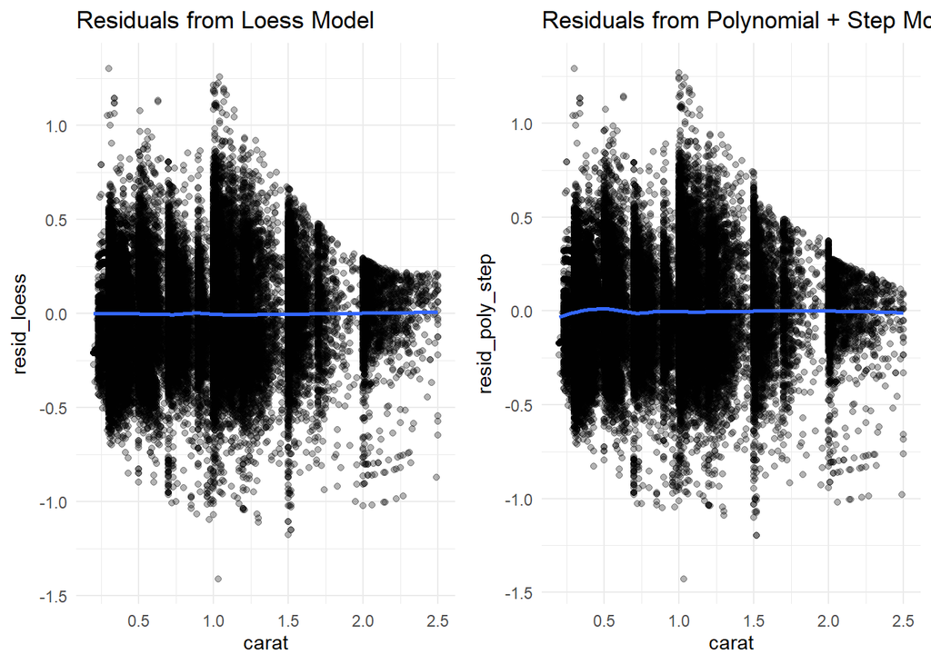

```r
diamonds_sub$resid_loess <- residuals(loess(log(price) ~ carat, data = diamonds_sub, span = 0.5))

p1 <- ggplot(diamonds_sub, aes(x = carat, y = resid_loess)) +
  geom_point(alpha = 0.3) +
  geom_smooth(method = "loess", se = FALSE) +
  labs(title = "Residuals from Loess Model") +
  theme_minimal()

p2 <- ggplot(diamonds_sub, aes(x = carat, y = resid_poly_step)) +
  geom_point(alpha = 0.3) +
  geom_smooth(method = "loess", se = FALSE) +
  labs(title = "Residuals from Polynomial + Step Model") +
  theme_minimal()

ggarrange(p1, p2, ncol = 2, nrow = 1)
```

The graphs show how loess was more effective in capturing the trend as it is less wavy compared to ploynomial + step model. #